# Diabetes and BMI - Simple Logistic Regression

#### Author: Gavin South

## Background

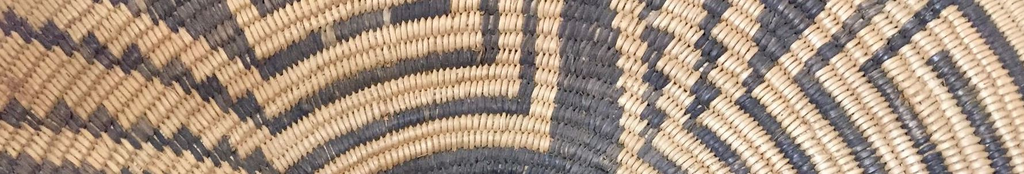

### Pima Indians

Growing up in Phoenix AZ, I rubbed shoulders with a wide variety of native American people. Although many of my friends and acquaintances were descendants of native American people and came from their respective families on reservations, many of them lived modern lifestyles that were far off from the traditional ways of life that existed only a few centuries ago. I also remember there being a high rate of obesity, heart failure, diabetes, alcoholism, and other health issues among native American people, because they have been exposed to and living the western American lifestyle. This lifestyle includes poor diet and substance abuse, which is totally new and unfamiliar to their genome. Because they’ve jumped into this lifestyle and continue to follow it, the health of some native people have been suffering. Outside parties have been trying to teach these groups better habits to avoid harmful diets and vices, but it’s a slow process. This study and the data being used to find trends among the Pima Indians and their diabetes rates gives a greater insight into how their `Body Mass Index` may be an predictor of whether or not they develop diabetes. To understand if there is a trend, future diet recommendations can be made and taught to the rising generation of these good people to ensure they can continue to live the best lives possible.

## Data

In this data set there is recorded health and body measurements for a large array of Pima Indian people. The two variables, or measurements, that are will be tested as a predictor for a diabetic diagnosis are; **`Body Mass Index`** and **`Outcome`**. (Diabetes, or no Diabetes)

| Pregnancies | Glucose | BloodPressure | SkinThickness | Insulin | BMI | DiabetesPedigreeFunction | Age | Outcome |
| --- | --- | --- | --- | --- | --- | --- | --- | --- |
| 6 | 148 | 72 | 35 | 0 | 33.6 | 0.627 | 50 | 1 |
| 1 | 85 | 66 | 29 | 0 | 26.6 | 0.351 | 31 | 0 |
| 8 | 183 | 64 | 0 | 0 | 23.3 | 0.672 | 32 | 1 |
| 1 | 89 | 66 | 23 | 94 | 28.1 | 0.167 | 21 | 0 |
| 0 | 137 | 40 | 35 | 168 | 43.1 | 2.288 | 33 | 1 |
| 5 | 116 | 74 | 0 | 0 | 25.6 | 0.201 | 30 | 0 |
| 3 | 78 | 50 | 32 | 88 | 31.0 | 0.248 | 26 | 1 |
| 10 | 115 | 0 | 0 | 0 | 35.3 | 0.134 | 29 | 0 |
| 2 | 197 | 70 | 45 | 543 | 30.5 | 0.158 | 53 | 1 |
| 4 | 110 | 92 | 0 | 0 | 37.6 | 0.191 | 30 | 0 |
| 10 | 168 | 74 | 0 | 0 | 38.0 | 0.537 | 34 | 1 |
| 10 | 139 | 80 | 0 | 0 | 27.1 | 1.441 | 57 | 0 |
| 1 | 189 | 60 | 23 | 846 | 30.1 | 0.398 | 59 | 1 |
| 5 | 166 | 72 | 19 | 175 | 25.8 | 0.587 | 51 | 1 |
| 7 | 100 | 0 | 0 | 0 | 30.0 | 0.484 | 32 | 1 |
| 0 | 118 | 84 | 47 | 230 | 45.8 | 0.551 | 31 | 1 |
| 7 | 107 | 74 | 0 | 0 | 29.6 | 0.254 | 31 | 1 |
| 1 | 103 | 30 | 38 | 83 | 43.3 | 0.183 | 33 | 0 |
| 1 | 115 | 70 | 30 | 96 | 34.6 | 0.529 | 32 | 1 |
| 3 | 126 | 88 | 41 | 235 | 39.3 | 0.704 | 27 | 0 |
| 8 | 99 | 84 | 0 | 0 | 35.4 | 0.388 | 50 | 0 |
| 7 | 196 | 90 | 0 | 0 | 39.8 | 0.451 | 41 | 1 |
| 9 | 119 | 80 | 35 | 0 | 29.0 | 0.263 | 29 | 1 |
| 11 | 143 | 94 | 33 | 146 | 36.6 | 0.254 | 51 | 1 |
| 10 | 125 | 70 | 26 | 115 | 31.1 | 0.205 | 41 | 1 |

## Logistic Model

#### Model

To model the probability of having diabetes at different BMIs a logistic regression model would be appropriate.

$$P(Y_i=1|x_i)=
\frac{e^{\beta_0 + \beta_1 x_i}}{1 + e^{\beta_0 + \beta_1 x_i}} =
\pi_i$$

Where the observation for $i$:

- $Y^i = 0$ where someone doesn’t have diabetes.
- $Y^i = 1$ where someone does have diabetes.
- $x_i$ is the BMI of said individual.

This is to test the odds of someone having diabetes ( 1 ) based off their BMI.

#### Hypotheses

$$H_0: \beta_1 = 0 \\
H_a: \beta_1 ≠ 0 \\
\text{level of significance:} \ \ a=0.05$$

The test will see if there is a relationship or if there is no relationship between xi and the log of the odds that Yi=1 In other words, xi is not useful in predicting the probability that Yi=1. If β1≠0 then there is information in xi that can be utilized to predict the probability that Yi=1, i.e., the logistic regression is meaningful.

#### Fitting the Model

The intercept for the test is $b_0= -3.99682$ which predicts $\beta_0$ and the slope $b_1= 0.10250$ which predicts $\beta_1$ for the BMI value.

The p-value from the test of BMI shows a significance result of **4.31e-16**. This result is so significant that there is irrefutable evidence that BMI affects the probability of someone having diabetes.

## Visualizing the Model

#### Plotting the Data

The following plot shows the logistic regression between these two variables. There is an obvious trend that reflects the results of the logistic regression test.

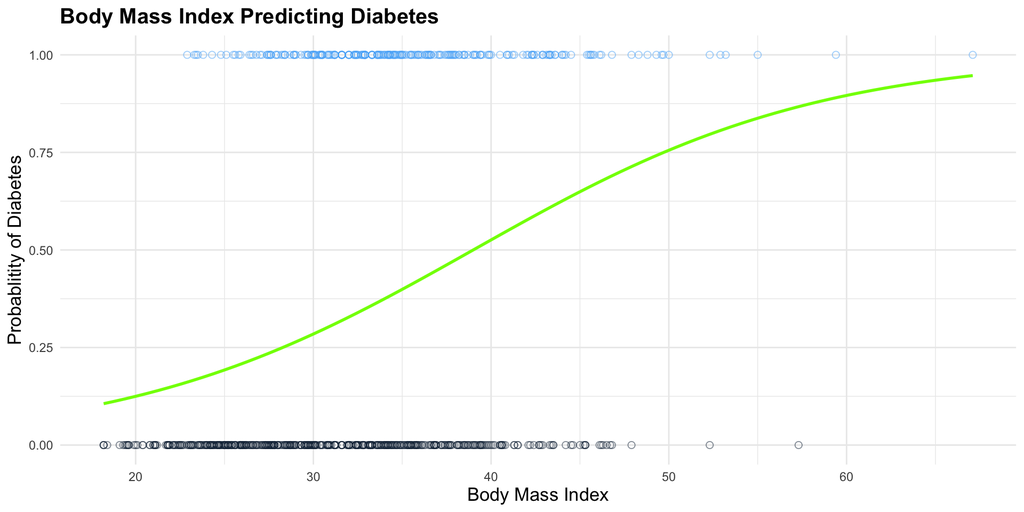

## Diagnosing The Model

#### Goodness of Fit

To verify that a logistic regression test is the best statistical analysis for this problem and data, another test can be employed to check the **goodness of fit.** The best test would be a Hosmer and Lemeshow goodness of fit because there are almost no repeating BMI values in the data set.

Hosmer and Lemeshow goodness of fit (GOF) test: `LogR$y, LogR$fitted.values`

| Test statistic | df | P value |
| --- | --- | --- |
| 52.47 | 48 | 0.3048 |

The **Hosmer and Lemeshow goodness of fit (GOF) test** results in a p-value that keeps the null-hypothesis claiming that a logistic regression is a great test option.

## Interpretation

#### Predictive Capabilities

The amazing part about a logistic regression is it’s predictive capability to take the quantifiable variable in a test, in this case `BMI` and predict the binary outcome of the model; `Diabetic or Not`. Based off this data set if a healthy person that was a Pima Indian wanted to know their likely hood of developing diabetes they would consider this:

The *CDC* says that peoples `BMI`’s fall under these ranges:

[output not shown]

[output not shown]

[output not shown]

[output not shown]